# WSP setup and demographics code

Lizzie Jones[^1]

02/05/2021

## WSP - Demographics exploration, analysis and visualisations

#### About this rMarkdown

This rMarkdown document will be periodically updated and uploaded to the OneDrive folder and pushed to the WSP GitHub code repository. The primary format of this document is HTML, but this can be easily changed by changing the output (e.g. PDF, GitHub) using the ‘output’ section at the top of the document. The possible output formats are listed here: https://rmarkdown.rstudio.com/lesson-9.html.

## Exploring respondent demographics

The distribution of gender and education is explored and compared between samples using stacked bar plots.

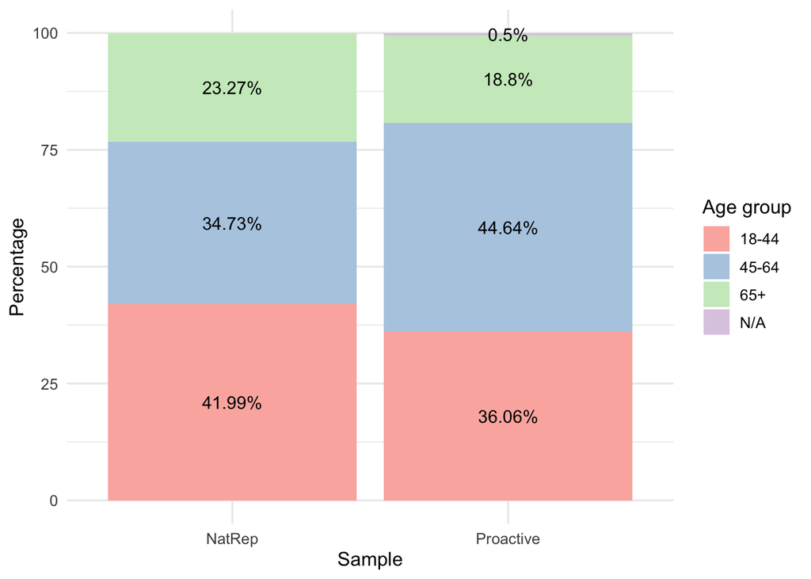

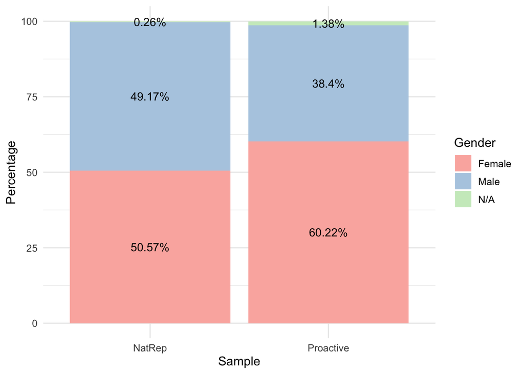

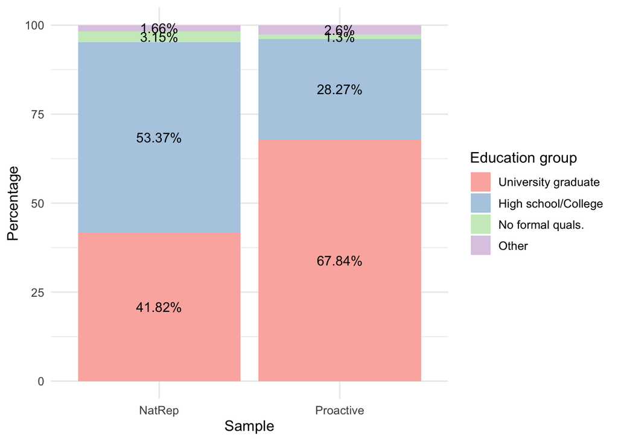

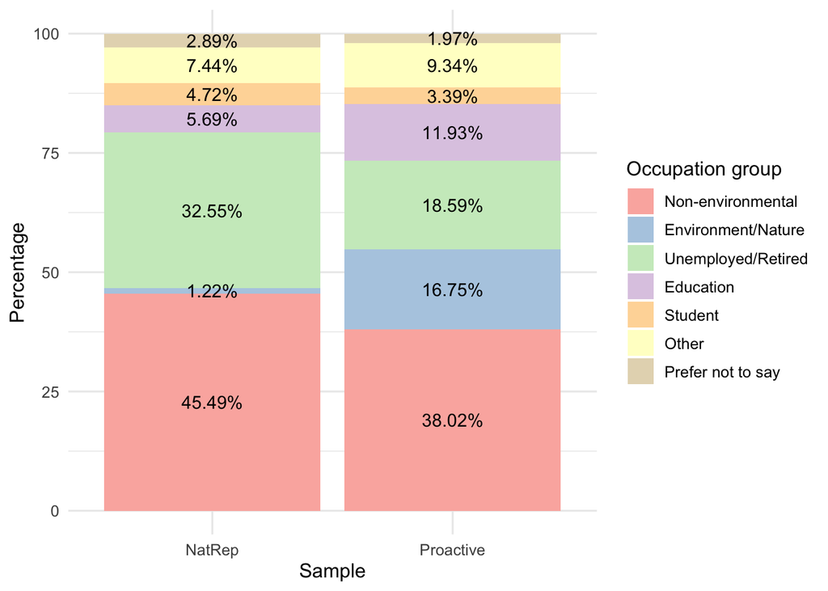

### Respondent demographics tables

The table below (created using the package “table1”) outlines the demographic characteriscs of each of the two samples, and the overall demographics of all respondents across both samples. For each demographic variable the tables provides a breakdown of the number of respondents within each level/group and the percentage.

|  | Nationally rep. Local (N=18) | Nationally rep. Not local (N=1125) | Proactive Local (N=1014) | Proactive Not local (N=1374) | Overall Local (N=1032) | Overall Not local (N=2499) |
| --- | --- | --- | --- | --- | --- | --- |
| Age group |  |  |  |  |  |  |
| 18-44 | 6 (33.3%) | 474 (42.1%) | 269 (26.5%) | 592 (43.1%) | 275 (26.6%) | 1066 (42.7%) |
| 45-64 | 8 (44.4%) | 389 (34.6%) | 505 (49.8%) | 561 (40.8%) | 513 (49.7%) | 950 (38.0%) |
| 65+ | 4 (22.2%) | 262 (23.3%) | 235 (23.2%) | 214 (15.6%) | 239 (23.2%) | 476 (19.0%) |
| N/A | 0 (0%) | 0 (0%) | 5 (0.5%) | 7 (0.5%) | 5 (0.5%) | 7 (0.3%) |
| Gender |  |  |  |  |  |  |
| Female | 10 (55.6%) | 568 (50.5%) | 690 (68.0%) | 748 (54.4%) | 700 (67.8%) | 1316 (52.7%) |
| Male | 8 (44.4%) | 554 (49.2%) | 314 (31.0%) | 603 (43.9%) | 322 (31.2%) | 1157 (46.3%) |
| N/A | 0 (0%) | 3 (0.3%) | 10 (1.0%) | 23 (1.7%) | 10 (1.0%) | 26 (1.0%) |
| Education |  |  |  |  |  |  |
| High school/College | 10 (55.6%) | 600 (53.3%) | 363 (35.8%) | 312 (22.7%) | 373 (36.1%) | 912 (36.5%) |
| No formal quals. | 1 (5.6%) | 35 (3.1%) | 16 (1.6%) | 15 (1.1%) | 17 (1.6%) | 50 (2.0%) |
| University graduate | 7 (38.9%) | 471 (41.9%) | 595 (58.7%) | 1025 (74.6%) | 602 (58.3%) | 1496 (59.9%) |
| Other | 0 (0%) | 19 (1.7%) | 40 (3.9%) | 22 (1.6%) | 40 (3.9%) | 41 (1.6%) |
| Occupation |  |  |  |  |  |  |
| Education | 1 (5.6%) | 64 (5.7%) | 137 (13.5%) | 148 (10.8%) | 138 (13.4%) | 212 (8.5%) |
| Non-environmental | 10 (55.6%) | 510 (45.3%) | 462 (45.6%) | 446 (32.5%) | 472 (45.7%) | 956 (38.3%) |
| Other | 1 (5.6%) | 84 (7.5%) | 106 (10.5%) | 117 (8.5%) | 107 (10.4%) | 201 (8.0%) |
| Unemployed/Retired | 6 (33.3%) | 366 (32.5%) | 193 (19.0%) | 251 (18.3%) | 199 (19.3%) | 617 (24.7%) |
| Environment/Nature | 0 (0%) | 14 (1.2%) | 81 (8.0%) | 319 (23.2%) | 81 (7.8%) | 333 (13.3%) |
| Prefer not to say | 0 (0%) | 33 (2.9%) | 23 (2.3%) | 24 (1.7%) | 23 (2.2%) | 57 (2.3%) |
| Student | 0 (0%) | 54 (4.8%) | 12 (1.2%) | 69 (5.0%) | 12 (1.2%) | 123 (4.9%) |
| Area type |  |  |  |  |  |  |
| Rural | 7 (38.9%) | 214 (19.0%) | 609 (60.1%) | 435 (31.7%) | 616 (59.7%) | 649 (26.0%) |
| Sub-urban | 6 (33.3%) | 534 (47.5%) | 305 (30.1%) | 551 (40.1%) | 311 (30.1%) | 1085 (43.4%) |
| Urban | 5 (27.8%) | 377 (33.5%) | 100 (9.9%) | 388 (28.2%) | 105 (10.2%) | 765 (30.6%) |

|  | Nationally rep. Local (N=18) | Nationally rep. Not local (N=1125) | Proactive Local (N=1014) | Proactive Not local (N=1374) | Overall Local (N=1032) | Overall Not local (N=2499) |
| --- | --- | --- | --- | --- | --- | --- |
| Age group |  |  |  |  |  |  |
| 18-24 | 1 (5.6%) | 124 (11.0%) | 21 (2.1%) | 112 (8.2%) | 22 (2.1%) | 236 (9.4%) |
| 25-34 | 1 (5.6%) | 172 (15.3%) | 82 (8.1%) | 251 (18.3%) | 83 (8.0%) | 423 (16.9%) |
| 35-44 | 4 (22.2%) | 178 (15.8%) | 166 (16.4%) | 229 (16.7%) | 170 (16.5%) | 407 (16.3%) |
| 45-54 | 5 (27.8%) | 199 (17.7%) | 241 (23.8%) | 247 (18.0%) | 246 (23.8%) | 446 (17.8%) |
| 55-64 | 3 (16.7%) | 190 (16.9%) | 264 (26.0%) | 314 (22.9%) | 267 (25.9%) | 504 (20.2%) |
| 65+ | 4 (22.2%) | 262 (23.3%) | 235 (23.2%) | 214 (15.6%) | 239 (23.2%) | 476 (19.0%) |
| Prefer not to answer | 0 (0%) | 0 (0%) | 5 (0.5%) | 7 (0.5%) | 5 (0.5%) | 7 (0.3%) |
| Gender |  |  |  |  |  |  |
| Female | 10 (55.6%) | 568 (50.5%) | 690 (68.0%) | 748 (54.4%) | 700 (67.8%) | 1316 (52.7%) |
| Male | 8 (44.4%) | 554 (49.2%) | 314 (31.0%) | 603 (43.9%) | 322 (31.2%) | 1157 (46.3%) |
| N/A | 0 (0%) | 3 (0.3%) | 10 (1.0%) | 23 (1.7%) | 10 (1.0%) | 26 (1.0%) |
| Education |  |  |  |  |  |  |
| Postgraduate degree | 0 (0%) | 153 (13.6%) | 249 (24.6%) | 495 (36.0%) | 249 (24.1%) | 648 (25.9%) |
| Undergraduate degree | 7 (38.9%) | 318 (28.3%) | 346 (34.1%) | 530 (38.6%) | 353 (34.2%) | 848 (33.9%) |
| Further Education | 3 (16.7%) | 209 (18.6%) | 172 (17.0%) | 157 (11.4%) | 175 (17.0%) | 366 (14.6%) |
| Secondary school | 7 (38.9%) | 391 (34.8%) | 191 (18.8%) | 155 (11.3%) | 198 (19.2%) | 546 (21.8%) |
| No formal qualifications | 1 (5.6%) | 35 (3.1%) | 16 (1.6%) | 15 (1.1%) | 17 (1.6%) | 50 (2.0%) |
| Prefer not to answer | 0 (0%) | 18 (1.6%) | 16 (1.6%) | 11 (0.8%) | 16 (1.6%) | 29 (1.2%) |
| Other | 0 (0%) | 1 (0.1%) | 24 (2.4%) | 11 (0.8%) | 24 (2.3%) | 12 (0.5%) |
| Occupation |  |  |  |  |  |  |
| Architecture, Energy & Engineering | 0 (0%) | 29 (2.6%) | 16 (1.6%) | 24 (1.7%) | 16 (1.6%) | 53 (2.1%) |
| Arts, Sport & Media | 1 (5.6%) | 19 (1.7%) | 50 (4.9%) | 62 (4.5%) | 51 (4.9%) | 81 (3.2%) |
| Building & Maintenance | 1 (5.6%) | 20 (1.8%) | 14 (1.4%) | 8 (0.6%) | 15 (1.5%) | 28 (1.1%) |
| Business & Finance | 1 (5.6%) | 72 (6.4%) | 68 (6.7%) | 60 (4.4%) | 69 (6.7%) | 132 (5.3%) |
| Community & Social Service | 0 (0%) | 16 (1.4%) | 26 (2.6%) | 26 (1.9%) | 26 (2.5%) | 42 (1.7%) |
| Computer & Mathematical | 1 (5.6%) | 30 (2.7%) | 33 (3.3%) | 37 (2.7%) | 34 (3.3%) | 67 (2.7%) |
| Education | 1 (5.6%) | 64 (5.7%) | 137 (13.5%) | 148 (10.8%) | 138 (13.4%) | 212 (8.5%) |
| Environment, Nature & Wildlife | 0 (0%) | 5 (0.4%) | 54 (5.3%) | 285 (20.7%) | 54 (5.2%) | 290 (11.6%) |
| Farming & Agriculture | 0 (0%) | 6 (0.5%) | 16 (1.6%) | 17 (1.2%) | 16 (1.6%) | 23 (0.9%) |
| Fisheries & Aquaculture | 0 (0%) | 1 (0.1%) | 1 (0.1%) | 9 (0.7%) | 1 (0.1%) | 10 (0.4%) |
| Forestry & Woodland Management | 0 (0%) | 0 (0%) | 7 (0.7%) | 9 (0.7%) | 7 (0.7%) | 9 (0.4%) |
| Healthcare | 1 (5.6%) | 87 (7.7%) | 93 (9.2%) | 72 (5.2%) | 94 (9.1%) | 159 (6.4%) |
| Homemaker / Carer | 0 (0%) | 16 (1.4%) | 20 (2.0%) | 7 (0.5%) | 20 (1.9%) | 23 (0.9%) |
| Horticulture/Gardening/Landscaping | 0 (0%) | 2 (0.2%) | 10 (1.0%) | 8 (0.6%) | 10 (1.0%) | 10 (0.4%) |
| Hospitality | 1 (5.6%) | 39 (3.5%) | 14 (1.4%) | 17 (1.2%) | 15 (1.5%) | 56 (2.2%) |
| Law/Legal | 0 (0%) | 4 (0.4%) | 5 (0.5%) | 7 (0.5%) | 5 (0.5%) | 11 (0.4%) |
| Office and Administrative Support | 3 (16.7%) | 78 (6.9%) | 60 (5.9%) | 59 (4.3%) | 63 (6.1%) | 137 (5.5%) |
| Other | 1 (5.6%) | 84 (7.5%) | 106 (10.5%) | 117 (8.5%) | 107 (10.4%) | 201 (8.0%) |
| Physical and Social Science | 0 (0%) | 5 (0.4%) | 8 (0.8%) | 10 (0.7%) | 8 (0.8%) | 15 (0.6%) |
| Prefer not to answer | 0 (0%) | 33 (2.9%) | 23 (2.3%) | 24 (1.7%) | 23 (2.2%) | 57 (2.3%) |
| Production | 0 (0%) | 14 (1.2%) | 7 (0.7%) | 13 (0.9%) | 7 (0.7%) | 27 (1.1%) |
| Retired | 4 (22.2%) | 261 (23.2%) | 171 (16.9%) | 211 (15.4%) | 175 (17.0%) | 472 (18.9%) |
| Sales | 1 (5.6%) | 48 (4.3%) | 19 (1.9%) | 12 (0.9%) | 20 (1.9%) | 60 (2.4%) |
| Student | 0 (0%) | 54 (4.8%) | 12 (1.2%) | 69 (5.0%) | 12 (1.2%) | 123 (4.9%) |
| Tourism | 0 (0%) | 6 (0.5%) | 6 (0.6%) | 9 (0.7%) | 6 (0.6%) | 15 (0.6%) |
| Transport | 0 (0%) | 27 (2.4%) | 16 (1.6%) | 14 (1.0%) | 16 (1.6%) | 41 (1.6%) |
| Unemployed | 2 (11.1%) | 105 (9.3%) | 22 (2.2%) | 40 (2.9%) | 24 (2.3%) | 145 (5.8%) |
| Area type |  |  |  |  |  |  |
| Rural | 7 (38.9%) | 214 (19.0%) | 609 (60.1%) | 435 (31.7%) | 616 (59.7%) | 649 (26.0%) |
| Sub-urban | 6 (33.3%) | 534 (47.5%) | 305 (30.1%) | 551 (40.1%) | 311 (30.1%) | 1085 (43.4%) |
| Urban | 5 (27.8%) | 377 (33.5%) | 100 (9.9%) | 388 (28.2%) | 105 (10.2%) | 765 (30.6%) |

### Respondent postcode mapping

Maps of respondent location, seperating respondents according to survey type. The map indicates location using the first 4 digits of postcode (e.g., TN28), and points are colour-coded according to survey type.

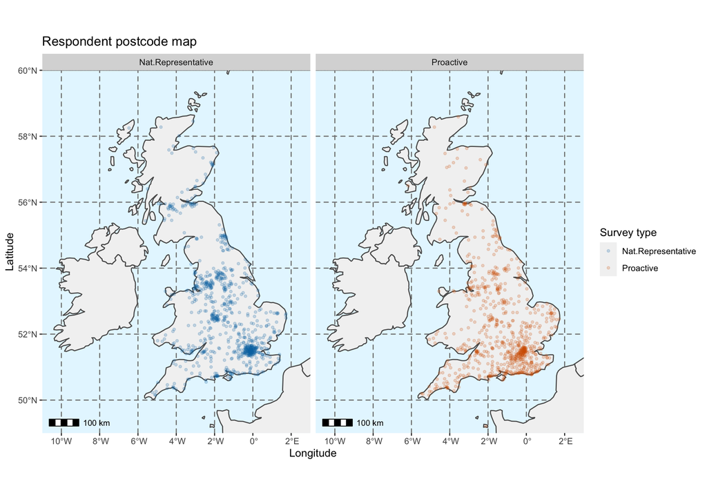

### Mapping proximity to WSP release sites

Maps of each WSP release site and a 15km radius encompassing the ‘local area’ as referred to in the main manuscript. The following code creates an interactive map of each site on an Open Street Map base which can be explored like a Google map.

I have also created this map as an interactive Shiny object (hosted via Shiny.io in my personal account but this can be transferred over to a Project account later on). The map is accessible via this link: https://ljones42.shinyapps.io/WSP_site_map/

The code file for this is in the Shiny file called ‘app.R’, which can be updated, run and pushed to the server.

```r
# Define data frame of site names and coordinates
marker_df <- read.csv(textConnection(
"Name,Lat,Long
Knepp,50.98341,-0.35485
Wadhurst,51.03579,0.32769
Wintershall,51.16605,-0.55289"))

## Create map iusing Leaflet
uk_map <- leaflet(marker_df) %>%
  addTiles() %>%
  setView(lng=-0.35485, lat=50.98341, zoom = 9) %>%  # Set view to local area and zoom
  addMarkers(lng=~Long, lat=~Lat, popup = ~htmltools::htmlEscape(Name)) %>%
  addCircles(lng=-0.35485, lat=50.98341, color = "red", radius = 15000) %>%
  addCircles(lng=0.32769, lat=51.03579, color = "blue", radius = 15000) %>%
  addCircles(lng=-0.55289, lat=51.16605, color = "green", radius = 15000) %>%
  addMeasure() %>% # Add scale and ability to manually measure distance between points
  addMiniMap() # Add in a small minimap of wider area
uk_map
```

[interactive chart not shown]

[^1]: University of Brighton, l.jones4@brighton.ac.uk